# CMPINF 2130 Summer 2021 - Week 03

Points, text, lines, and paths

Dr. Joseph P. Yurko

6/1/2021

## Load packages

```r
library(tidyverse)
```

## Anscombe data

```r
anscombe %>% glimpse()
```

```
## Rows: 11
## Columns: 8
## $ x1 <dbl> 10, 8, 13, 9, 11, 14, 6, 4, 12, 7, 5
## $ x2 <dbl> 10, 8, 13, 9, 11, 14, 6, 4, 12, 7, 5
## $ x3 <dbl> 10, 8, 13, 9, 11, 14, 6, 4, 12, 7, 5
## $ x4 <dbl> 8, 8, 8, 8, 8, 8, 8, 19, 8, 8, 8
## $ y1 <dbl> 8.04, 6.95, 7.58, 8.81, 8.33, 9.96, 7.24, 4.26, 10.84, 4.82, 5.68
## $ y2 <dbl> 9.14, 8.14, 8.74, 8.77, 9.26, 8.10, 6.13, 3.10, 9.13, 7.26, 4.74
## $ y3 <dbl> 7.46, 6.77, 12.74, 7.11, 7.81, 8.84, 6.08, 5.39, 8.15, 6.42, 5.73
## $ y4 <dbl> 6.58, 5.76, 7.71, 8.84, 8.47, 7.04, 5.25, 12.50, 5.56, 7.91, 6.89
```

The `anscombe` data are a wide object.

```r
anscombe
```

```
##    x1 x2 x3 x4    y1   y2    y3    y4
## 1  10 10 10  8  8.04 9.14  7.46  6.58
## 2   8  8  8  8  6.95 8.14  6.77  5.76
## 3  13 13 13  8  7.58 8.74 12.74  7.71
## 4   9  9  9  8  8.81 8.77  7.11  8.84
## 5  11 11 11  8  8.33 9.26  7.81  8.47
## 6  14 14 14  8  9.96 8.10  8.84  7.04
## 7   6  6  6  8  7.24 6.13  6.08  5.25
## 8   4  4  4 19  4.26 3.10  5.39 12.50
## 9  12 12 12  8 10.84 9.13  8.15  5.56
## 10  7  7  7  8  4.82 7.26  6.42  7.91
## 11  5  5  5  8  5.68 4.74  5.73  6.89
```

Last week we focused on the first data set, so the `x` and `y` variables that end in `"1"`. Let’s continue to focus on the first data set today.

```r
a1 <- anscombe %>%
  select(ends_with("1")) %>%
  rename(x = x1, y = y1)

a1 %>% glimpse()
```

```
## Rows: 11
## Columns: 2
## $ x <dbl> 10, 8, 13, 9, 11, 14, 6, 4, 12, 7, 5
## $ y <dbl> 8.04, 6.95, 7.58, 8.81, 8.33, 9.96, 7.24, 4.26, 10.84, 4.82, 5.68
```

Visualizing the relationship between `x` and `y` as a scatter plot.

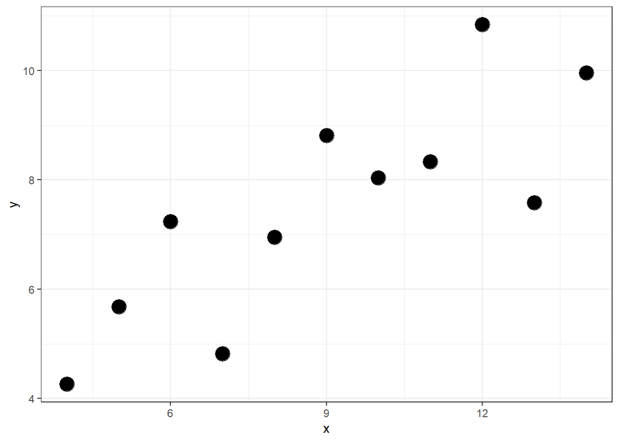

```r
a1 %>%
  ggplot(mapping = aes(x = x, y = y)) +
  geom_point(size = 5.5) +
  theme_bw()
```

Want to display text at specific points in the plot. It’s useful supplemental information. A simple type of supplemental information to display is the row order index on a point. Our data set does not include such an index.

```r
a1
```

```
##     x     y
## 1  10  8.04
## 2   8  6.95
## 3  13  7.58
## 4   9  8.81
## 5  11  8.33
## 6  14  9.96
## 7   6  7.24
## 8   4  4.26
## 9  12 10.84
## 10  7  4.82
## 11  5  5.68
```

We could manually add in a column for the row index, but the `tibble` package which is part of tidyverse has the `rowid_to_column()` to help out.

```r
a1 %>%
  tibble::rowid_to_column()
```

```
##    rowid  x     y
## 1      1 10  8.04
## 2      2  8  6.95
## 3      3 13  7.58
## 4      4  9  8.81
## 5      5 11  8.33
## 6      6 14  9.96
## 7      7  6  7.24
## 8      8  4  4.26
## 9      9 12 10.84
## 10    10  7  4.82
## 11    11  5  5.68
```

Include the rowid as text on the plot. The text is a geometric object. It has aesthetics, such as the `x` and `y` coordinate positions. And the `label` which is what we want to display at the position. There are two ways of showing text objects, the `geom_label()` and `geom_text()`.

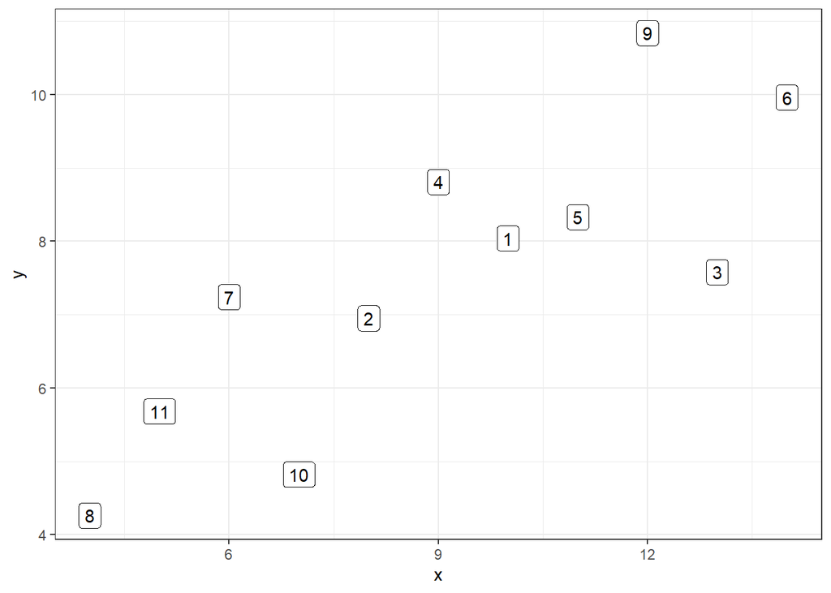

```r
a1 %>%
  tibble::rowid_to_column() %>%
  ggplot(mapping = aes(x = x, y = y)) +
  geom_label(mapping = aes(label = rowid)) +
  theme_bw()
```

If we change the theme to a dark them the label “bubble” by default is still white color.

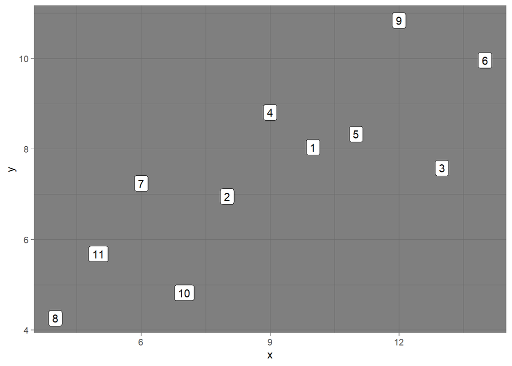

```r
a1 %>%
  tibble::rowid_to_column() %>%
  ggplot(mapping = aes(x = x, y = y)) +
  geom_label(mapping = aes(label = rowid)) +
  theme_dark()
```

`geom_text()` is more streamlined, it only shows the text label and does not include the “bubble” around the text.

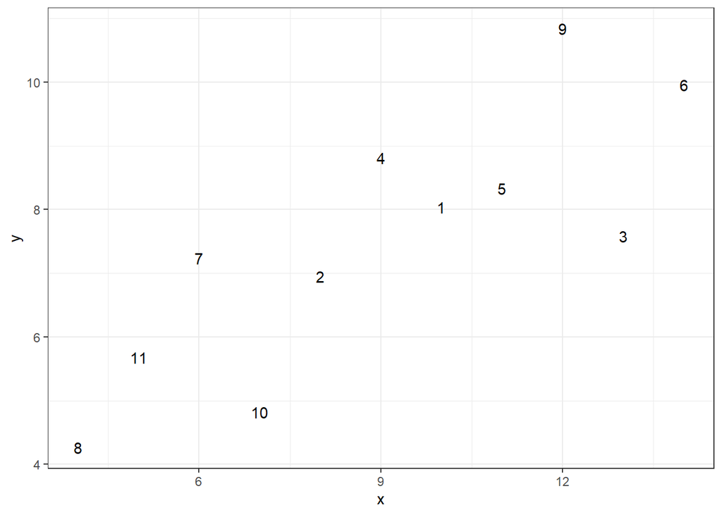

```r
a1 %>%
  tibble::rowid_to_column() %>%
  ggplot(mapping = aes(x = x, y = y)) +
  geom_text(mapping = aes(label = rowid)) +
  theme_bw()
```

We can modify the size of the text with the `size` aesthetic.

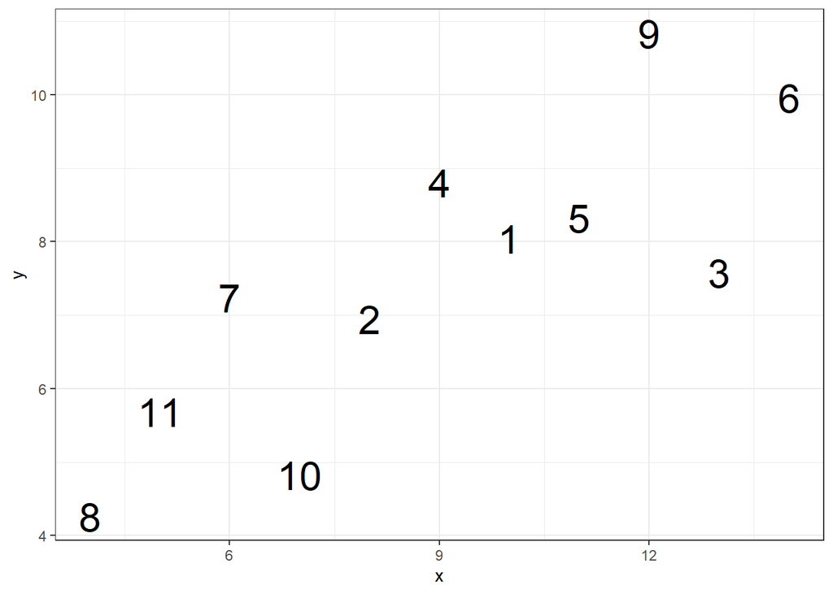

```r
a1 %>%
  tibble::rowid_to_column() %>%
  ggplot(mapping = aes(x = x, y = y)) +
  geom_text(mapping = aes(label = rowid),
            size = 8.5) +
  theme_bw()
```

We can also change the color.

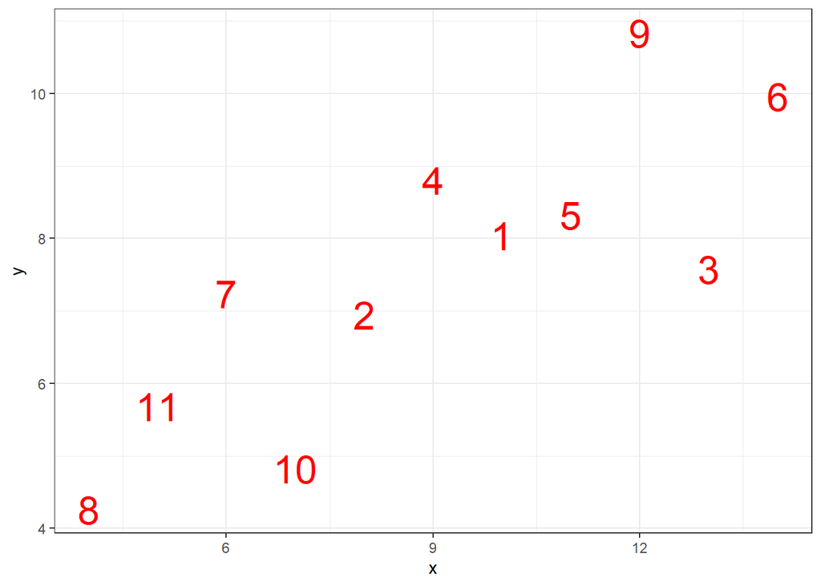

```r
a1 %>%
  tibble::rowid_to_column() %>%
  ggplot(mapping = aes(x = x, y = y)) +
  geom_text(mapping = aes(label = rowid),
            size = 8.5, color = 'red') +
  theme_bw()
```

We can combine multiple geometric objects together to creat a multi layered graphic. We add layers together to “build up” the final graphic.

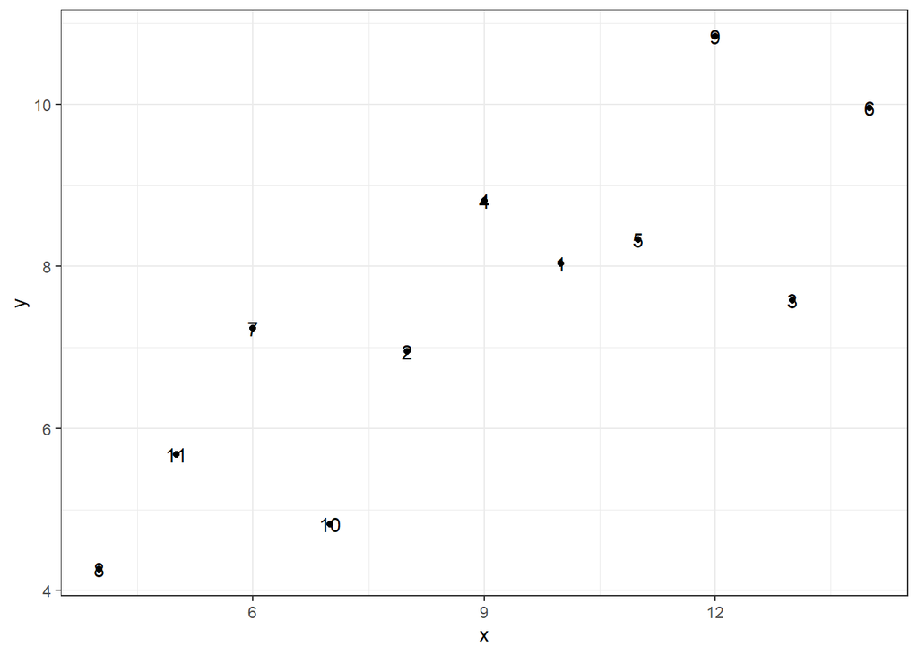

```r
a1 %>%
  tibble::rowid_to_column() %>%
  ggplot(mapping = aes(x = x, y = y)) +
  geom_point() +
  geom_text(mapping = aes(label = rowid)) +
  theme_bw()
```

Let’s modify the points so that we have larger points of a darker color with text of a lighter color on top.

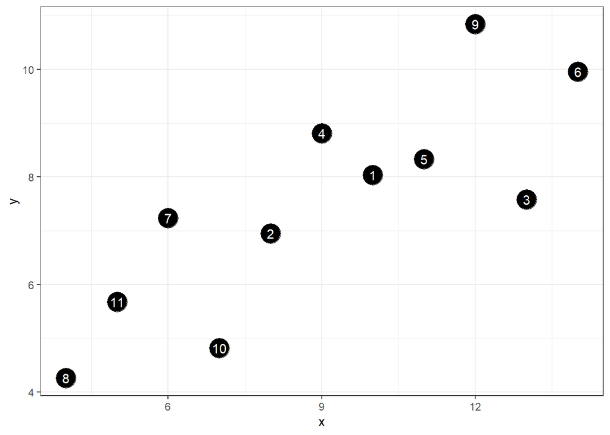

```r
a1 %>%
  tibble::rowid_to_column() %>%
  ggplot(mapping = aes(x = x, y = y)) +
  geom_point(size = 7.5, color = 'black') +
  geom_text(mapping = aes(label = rowid),
            color = 'white') +
  theme_bw()
```

Text aesthetics can be mapped to variables in the data set. So let’s try the text color and size mapped to the rowid.

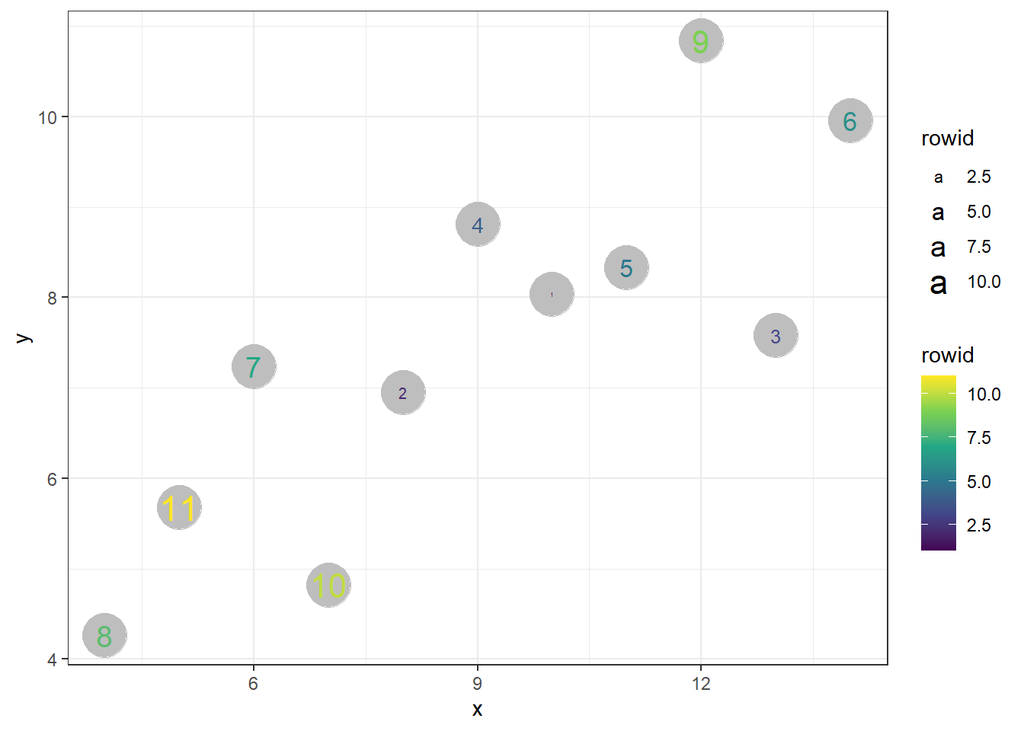

```r
a1 %>%
  tibble::rowid_to_column() %>%
  ggplot(mapping = aes(x = x, y = y)) +
  geom_point(size = 10, color = 'grey') +
  geom_text(mapping = aes(label = rowid,
                          color = rowid,
                          size = rowid)) +
  scale_color_viridis_c() +
  scale_size_continuous() +
  theme_bw()
```

So let’s use a fill aesthetic for the markers and a color aesthetic for the font color. Specify a marker shape that has both fill and color stroke.

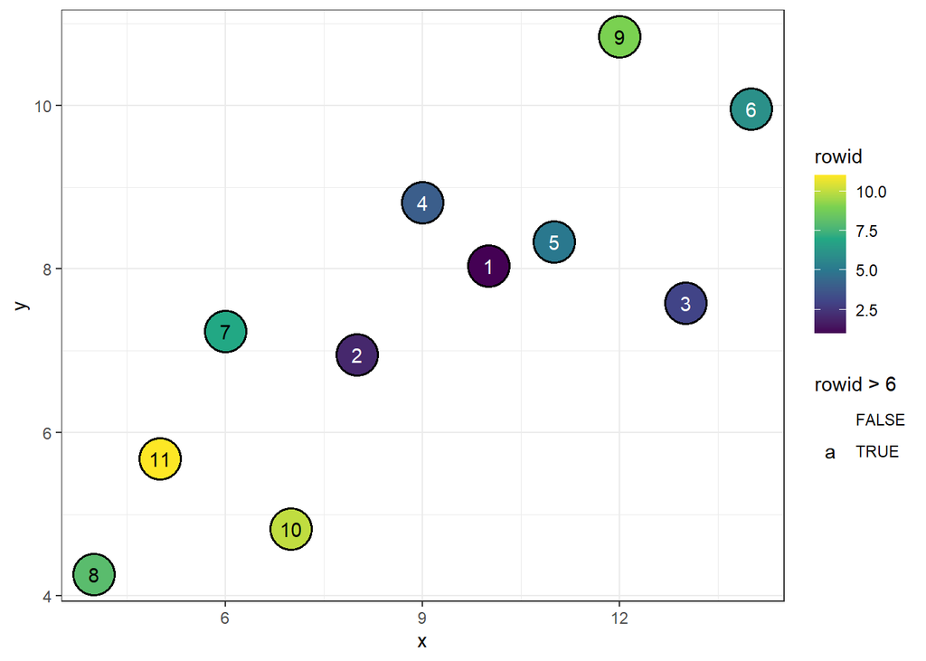

```r
a1 %>%
  tibble::rowid_to_column() %>%
  ggplot(mapping = aes(x = x, y = y)) +
  geom_point(size = 10,
             mapping = aes(fill = rowid),
             shape = 21, color = 'black', stroke = 1.) +
  geom_text(mapping = aes(label = rowid,
                          color = rowid > 6)) +
  scale_fill_viridis_c() +
  scale_color_manual(values = c("TRUE" = 'black',
                                "FALSE" = 'white')) +
  theme_bw()
```

Turn off the legend guide for the text color and the marker fill.

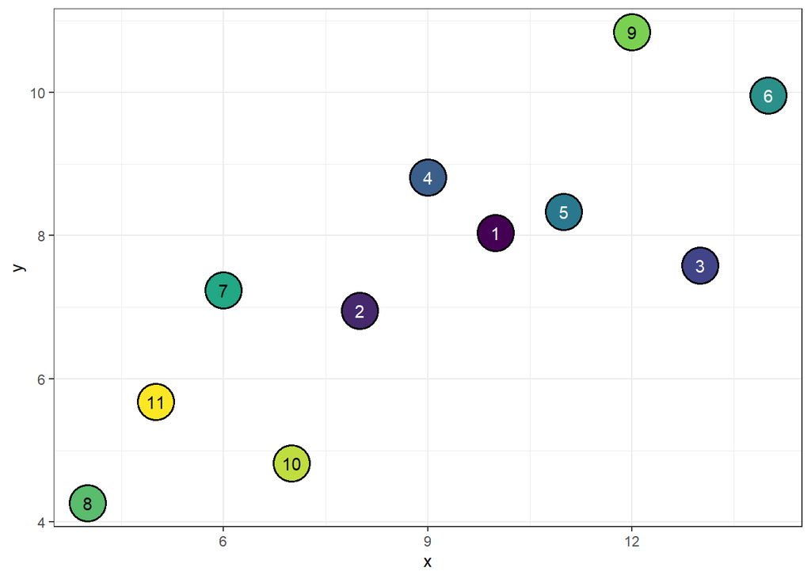

```r
a1 %>%
  tibble::rowid_to_column() %>%
  ggplot(mapping = aes(x = x, y = y)) +
  geom_point(size = 10,
             mapping = aes(fill = rowid),
             shape = 21, color = 'black', stroke = 1.) +
  geom_text(mapping = aes(label = rowid,
                          color = rowid > 6)) +
  scale_fill_viridis_c(guide = FALSE) +
  scale_color_manual(guide = FALSE,
                     values = c("TRUE" = 'black',
                                "FALSE" = 'white')) +
  theme_bw()
```

## Lines and paths

When we want to express continuity we want to use lines. The `geom_line()` lets us express continuity in the x-axis variable. So `geom_line()` connects **sequential** points based on the value of the `x` aesthetic. For small data sets, I like to combine `geom_line()` and `geom_point()` so I can see the exact data points getting connected. To see why let’s first just look at the `geom_line()`.

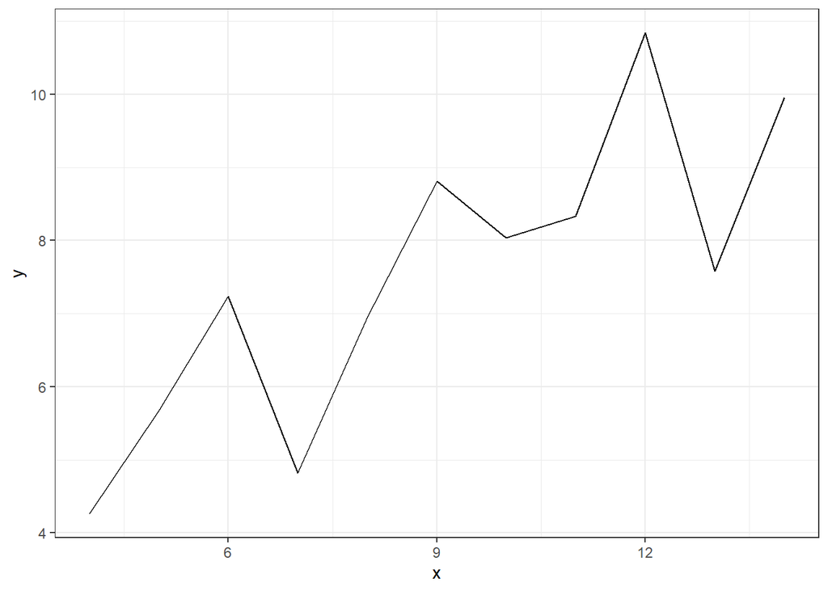

```r
a1 %>%
  ggplot(mapping = aes(x = x, y = y)) +
  geom_line() +
  theme_bw()
```

Combining the line with the points lets us see that the “kinks” or the “mountain tops” are associated with data points.

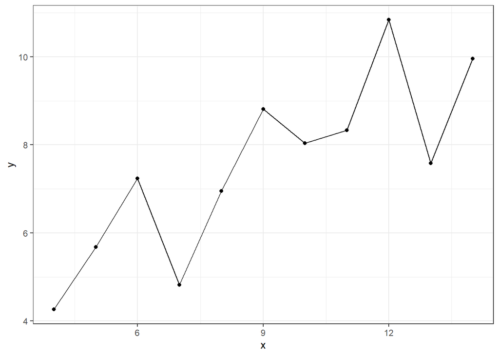

```r
a1 %>%
  ggplot(mapping = aes(x = x, y = y)) +
  geom_line() +
  geom_point() +
  theme_bw()
```

The line is choppy because there’s scatter in the data. Lines have aesthetics size is the line thickness, `linetype` controls if the line is solid, dashed, dotted, etc…

Let’s now combine the point, the text, and the line in our graphic.

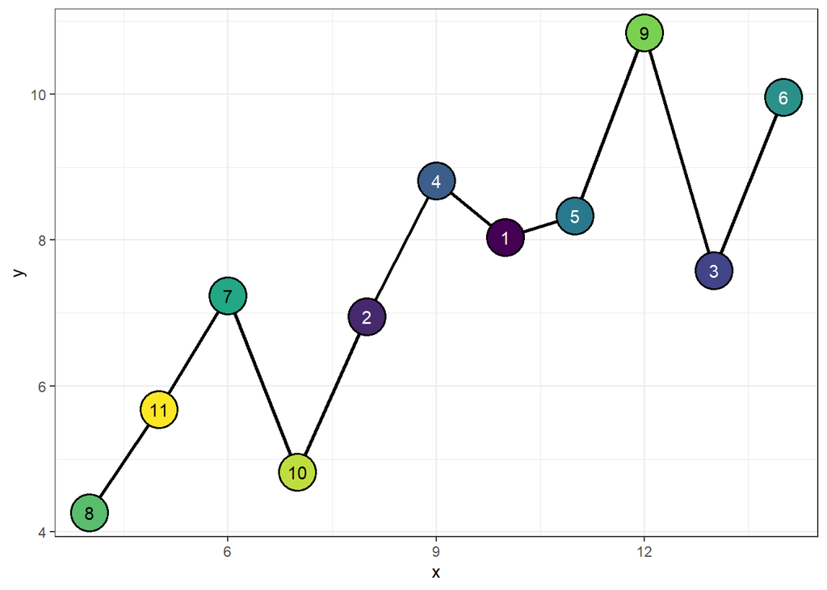

```r
a1 %>%
  tibble::rowid_to_column() %>%
  ggplot(mapping = aes(x = x, y = y)) +
  geom_line(size = 1.) +
  geom_point(size = 10,
             mapping = aes(fill = rowid),
             shape = 21, color = 'black', stroke = 1.) +
  geom_text(mapping = aes(label = rowid,
                          color = rowid > 6)) +
  scale_fill_viridis_c(guide = FALSE) +
  scale_color_manual(guide = FALSE,
                     values = c("TRUE" = 'black',
                                "FALSE" = 'white')) +
  theme_bw()
```

There is another way to express continuity…we can consider the row order in the data set. The `geom_path()` object connects points as the appear in the data.

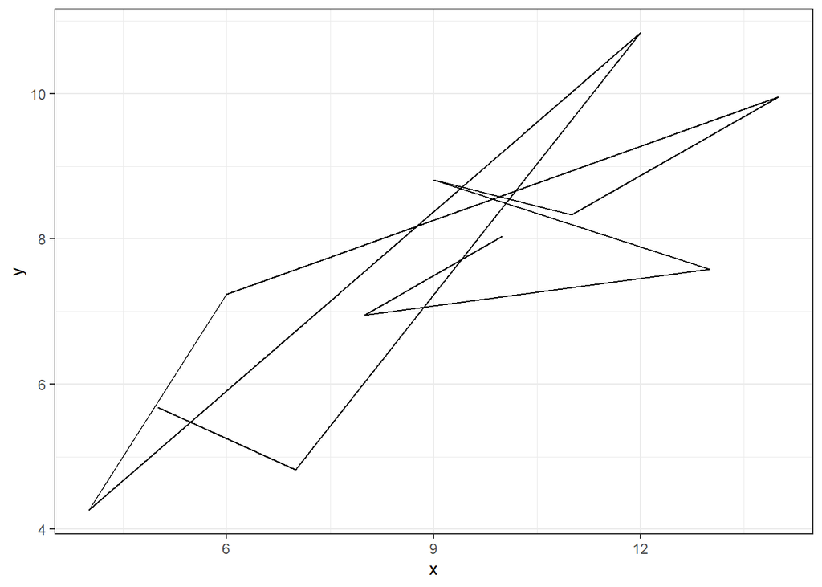

```r
a1 %>%
  ggplot(mapping = aes(x = x, y = y)) +
  geom_path() +
  theme_bw()
```

Why is it all over the place? Because the “path” follows the sequential ROW ORDER **not** the sequential x-axis ordering.

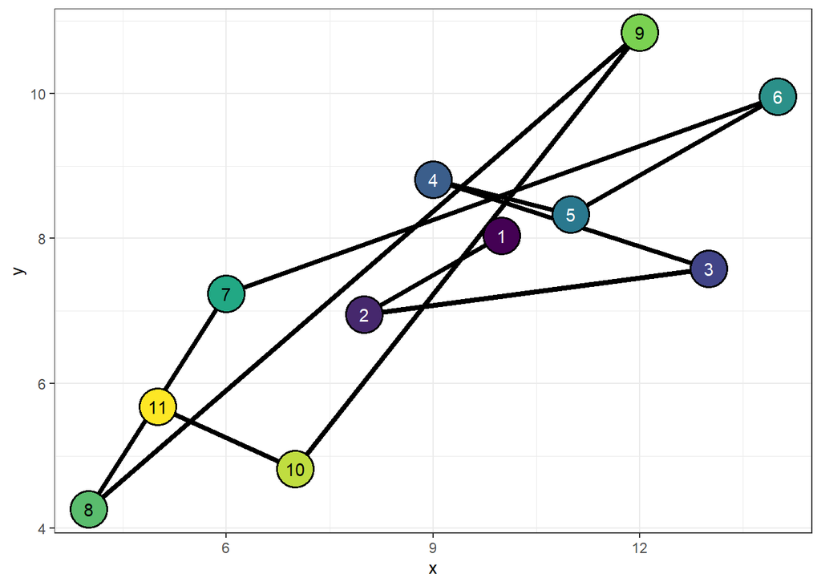

```r
a1 %>%
  tibble::rowid_to_column() %>%
  ggplot(mapping = aes(x = x, y = y)) +
  geom_path(size = 1.55) +
  geom_point(size = 10,
             mapping = aes(fill = rowid),
             shape = 21, color = 'black', stroke = 1.) +
  geom_text(mapping = aes(label = rowid,
                          color = rowid > 6)) +
  scale_fill_viridis_c(guide = FALSE) +
  scale_color_manual(guide = FALSE,
                     values = c("TRUE" = 'black',
                                "FALSE" = 'white')) +
  theme_bw()
```

Combine the `geom_line()` and the `geom_path()` a thick transparent for the path and a red dashed line for the sequential x-axis line.

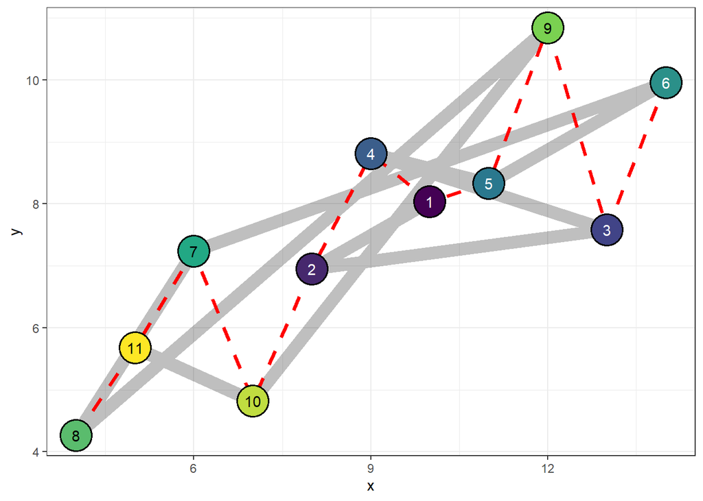

```r
a1 %>%
  tibble::rowid_to_column() %>%
  ggplot(mapping = aes(x = x, y = y)) +
  geom_path(size = 4.5, color = 'black', alpha = 0.25) +
  geom_line(size = 1.25, color = 'red', linetype = 'dashed') +
  geom_point(size = 10,
             mapping = aes(fill = rowid),
             shape = 21, color = 'black', stroke = 1.) +
  geom_text(mapping = aes(label = rowid,
                          color = rowid > 6)) +
  scale_fill_viridis_c(guide = FALSE) +
  scale_color_manual(guide = FALSE,
                     values = c("TRUE" = 'black',
                                "FALSE" = 'white')) +
  theme_bw()
```

The “best fit line” or regression line requires a statistical transformation and is considered its own geometric object. In ggplot2 it’s known as the `geom_smooth()`. One way to “smooth” is with a linear trend. By default the `geom_smooth()` allows for a non-linear smoother, and so to force a linear relationship which want to specify `method = lm` and the `formula = y ~ x`.

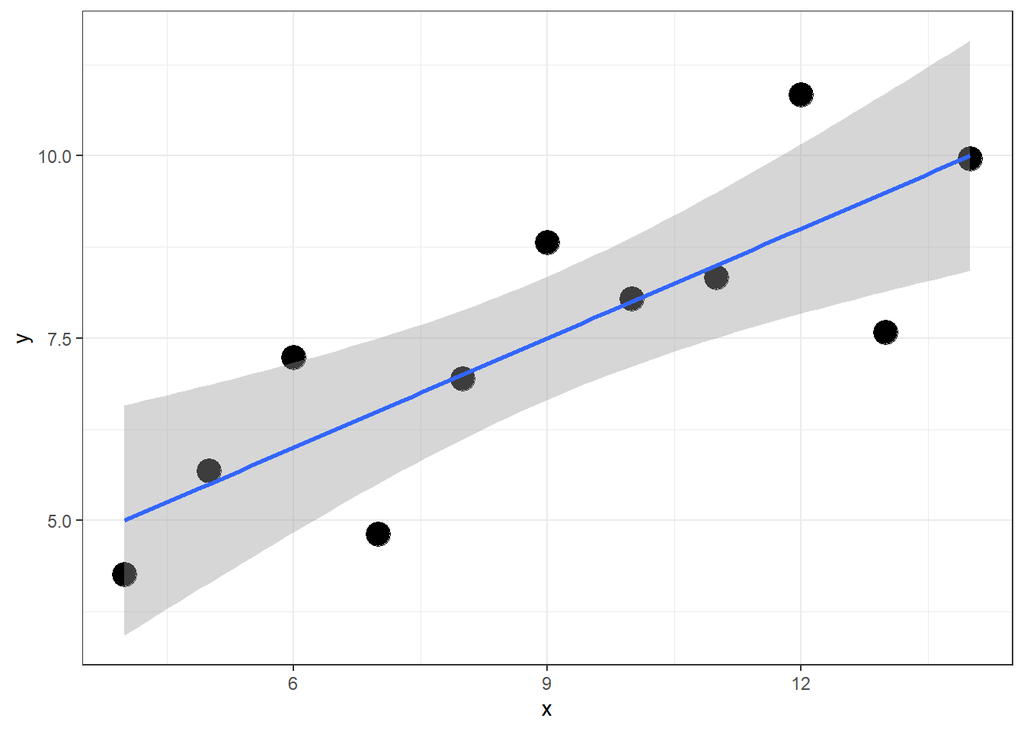

```r
a1 %>%
  ggplot(mapping = aes(x = x, y = y)) +
  geom_point(size = 5.5) +
  geom_smooth(method = lm) +
  theme_bw()
```

Specify the formula to remove the message.

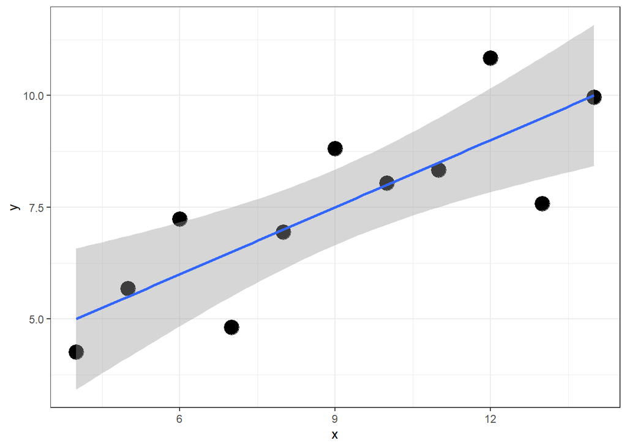

```r
a1 %>%
  ggplot(mapping = aes(x = x, y = y)) +
  geom_point(size = 5.5) +
  geom_smooth(formula = y ~ x,
              method = lm) +
  theme_bw()
```

To turn off the confidence interval set `se = FALSE`.

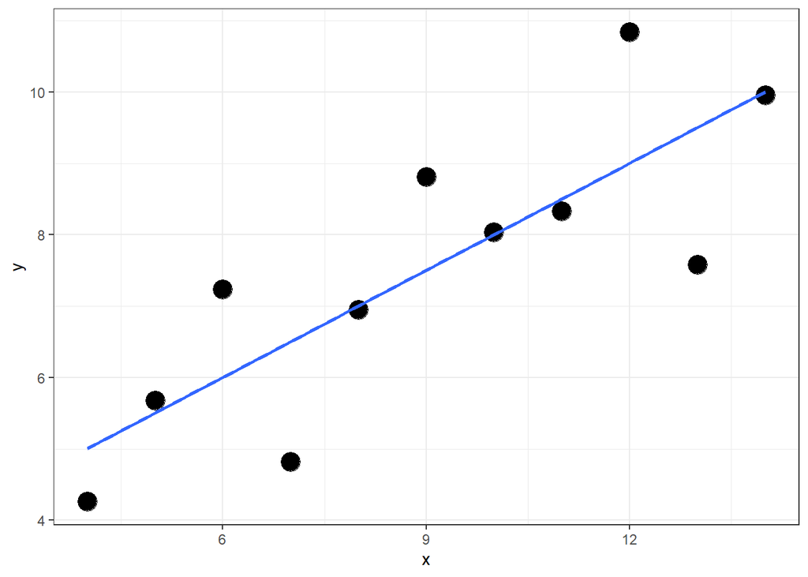

```r
a1 %>%
  ggplot(mapping = aes(x = x, y = y)) +
  geom_point(size = 5.5) +
  geom_smooth(formula = y ~ x,
              method = lm,
              se = FALSE) +
  theme_bw()
```

Combine the points, text, line, path, and trend.

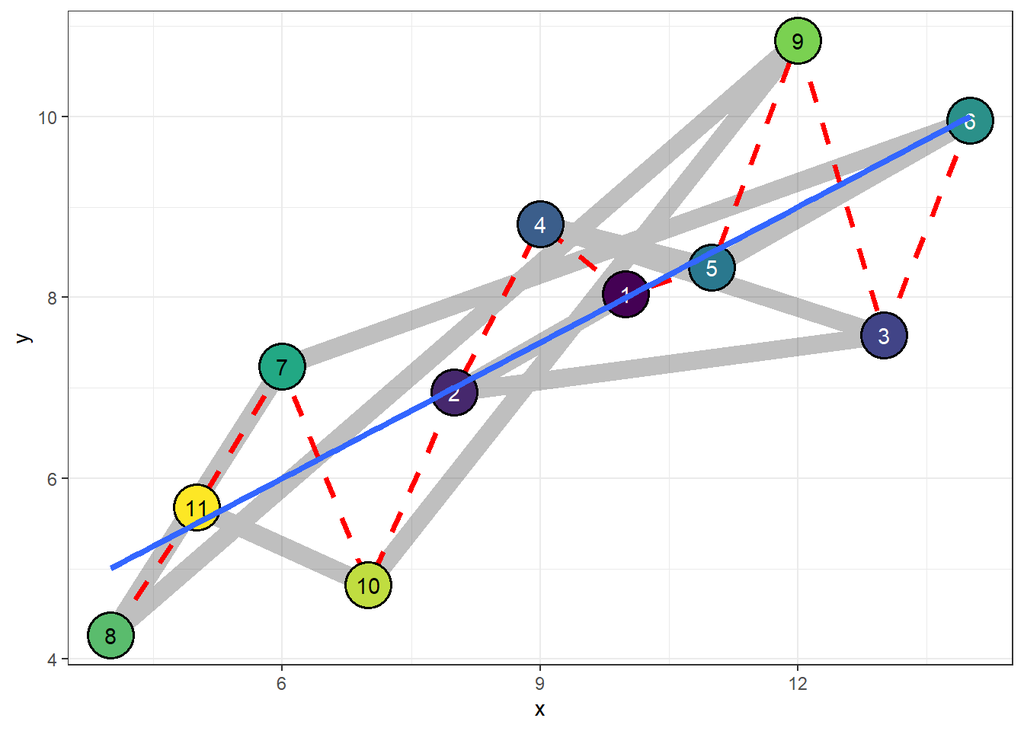

```r
a1 %>%
  tibble::rowid_to_column() %>%
  ggplot(mapping = aes(x = x, y = y)) +
  geom_path(size = 4.5, color = 'black', alpha = 0.25) +
  geom_line(size = 1.25, color = 'red', linetype = 'dashed') +
  geom_point(size = 10,
             mapping = aes(fill = rowid),
             shape = 21, color = 'black', stroke = 1.) +
  geom_text(mapping = aes(label = rowid,
                          color = rowid > 6)) +
  geom_smooth(formula = y ~ x,
              method = lm,
              se = FALSE,
              size = 1.55) +
  scale_fill_viridis_c(guide = FALSE) +
  scale_color_manual(guide = FALSE,
                     values = c("TRUE" = 'black',
                                "FALSE" = 'white')) +
  theme_bw()
```